# Gun Permit and Census Data Analysis

#### Author: Paul Glidden

- Introduction
- Gun Permit Data Wrangling
- Gun Permit Application Analysis
- Wrangle and Clean Census Data
- Analyze gun permit applications and census data
- Conclusions

#### Introduction

> During this analysis we wish to build answers to the following questions:

> > 1: Which states have had the highest growth in gun permit applications?  
> > 2: Are there additional idiosyncracies related to gun permit applications?  
> > 3: What is the overall trend of gun purchases in the United States?  
> > 4: What census data is most associated with high gun permit applications per state?

[output not shown]

#### Gun Permit Application Data Wrangling

> Begin by eading in the data and doing some basic cleaning to ensure it meets our needs. Date and percent change values need to be added for analysis

```
1998-11-01 00:00:00
2017-09-01 00:00:00
```

### Gun Permit Application Analysis

| state | percentChange |
| --- | --- |
| Iowa | 0.048321 |
| Mississippi | 0.044823 |
| North Carolina | 0.035097 |
| Nebraska | 0.034799 |
| Arkansas | 0.033189 |
| Alabama | 0.033168 |
| Kansas | 0.030958 |
| Hawaii | 0.029536 |
| Louisiana | 0.028719 |
| Maryland | 0.028254 |

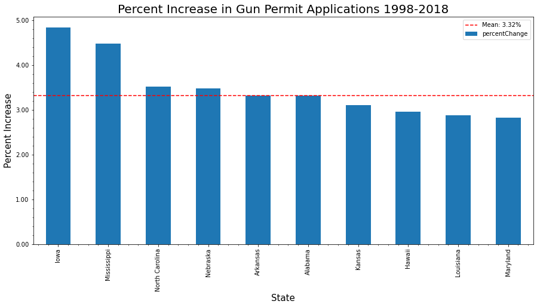

##### Exploring Permit Applications In Iowa

Iowa was the state with the highest growth in gun permit applications. Using the graph below we can see there is extensive variability month-to-month but overall the trend continued in an upward fashion

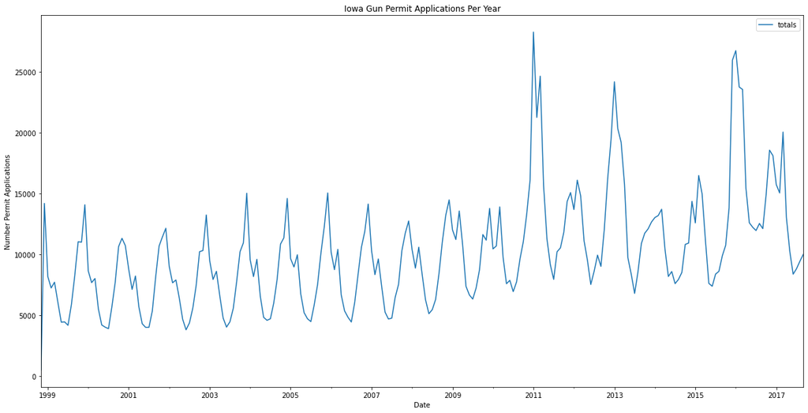

#### Exploring Utah

Exploring other states such as Utah shows aberations in the overall permit application trends. Utah shows a large spike in permit applications from in 2010-2012. NCIS data alone does not account for this trend and another source should be found.

An external influence caused the significant increase in permit applications and additional investigation into this external influence is required to provide further clarity. This pattern was seen in other states as well, so the influence outside of raw census information may have been more widespread than just a single state.

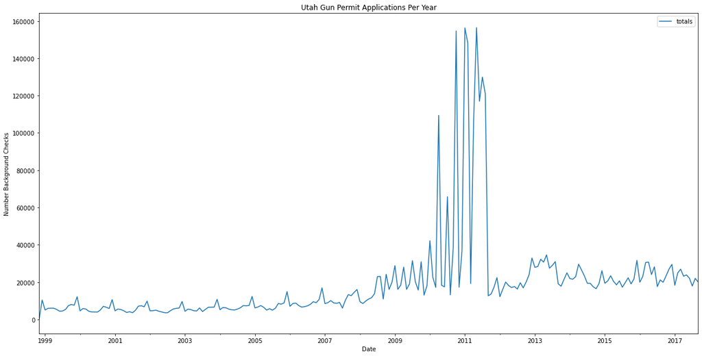

#### Gun purchase trends 1998-2018

Gun trends generally remained generally flat from 1998 to 2006. Beginning in 2006 though gun sales began to increase, and that increase only grew beginning in 2008 through 2016. Census data alone does not explain this large growth in gun permit applications. Additional research should be done to determine other possible causes of this growth.

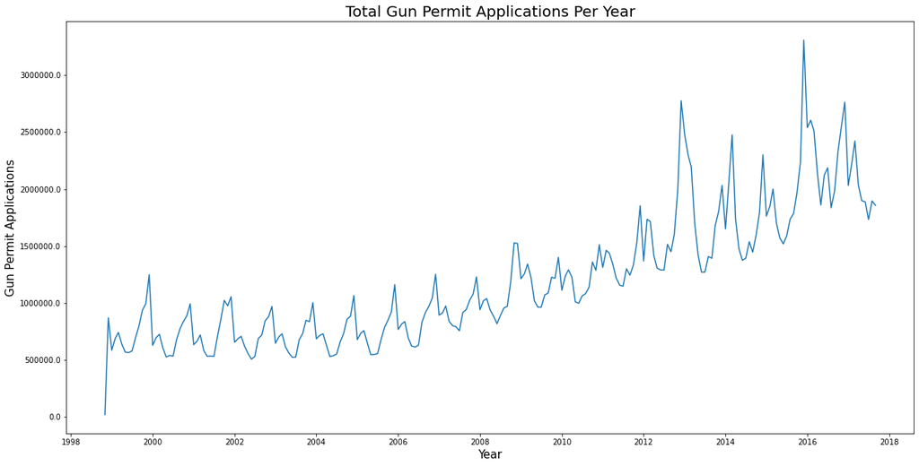

### Wrangle and Clean Census Data

Census data from April 2010 - July 2016 was used as part of this analysis. Alone this data does not add value to any analysis related to gun permit applications, so we must combine it with the totals from the NCIS gun database

```
<class 'pandas.core.frame.DataFrame'>
RangeIndex: 64 entries, 0 to 63
Data columns (total 51 columns):
 #   Column          Non-Null Count  Dtype
---  ------          --------------  -----
 0   Fact            64 non-null     object
 1   Alabama         64 non-null     object
 2   Alaska          64 non-null     object
 3   Arizona         64 non-null     object
 4   Arkansas        64 non-null     object
 5   California      64 non-null     object
 6   Colorado        64 non-null     object
 7   Connecticut     64 non-null     object
 8   Delaware        64 non-null     object
 9   Florida         64 non-null     object
```

[output cut: 43 more lines]

```
Alabama
Alaska
Arizona
Arkansas
California
Colorado
Connecticut
Delaware
Florida
Georgia
Hawaii
Idaho
Illinois
Indiana
Iowa
Kansas
Kentucky
Louisiana
Maine
Maryland
Massachusetts
Michigan
Minnesota
Mississippi
Missouri
Montana
Nebraska
Nevada
New Hampshire
New Jersey
New Mexico
New York
North Carolina
North Dakota
Ohio
Oklahoma
Oregon
Pennsylvania
Rhode Island
South Carolina
South Dakota
Tennessee
Texas
Utah
Vermont
Virginia
Washington
West Virginia
Wisconsin
Wyoming
```

```
<class 'pandas.core.frame.DataFrame'>
Index: 55 entries, Alabama to Wyoming
Data columns (total 65 columns):
 #   Column                                                                                  Non-Null Count  Dtype
---  ------                                                                                  --------------  -----
 0   totals                                                                                  55 non-null     int64
 1   Population estimates, July 1, 2016,  (V2016)                                            50 non-null     float64
 2   Population estimates base, April 1, 2010,  (V2016)                                      50 non-null     float64
 3   Population, percent change - April 1, 2010 (estimates base) to July 1, 2016,  (V2016)   50 non-null     float64
 4   Population, Census, April 1, 2010                                                       50 non-null     float64
 5   Persons under 5 years, percent, July 1, 2016,  (V2016)                                  50 non-null     float64
 6   Persons under 5 years, percent, April 1, 2010                                           50 non-null     float64
 7   Persons under 18 years, percent, July 1, 2016,  (V2016)                                 50 non-null     float64
 8   Persons under 18 years, percent, April 1, 2010                                          50 non-null     float64
 9   Persons 65 years and over, percent,  July 1, 2016,  (V2016)                             50 non-null     float64
```

[output cut: 57 more lines]

#### Analyze gun permit applications and census data

```
Total manufacturers shipments, 2012 ($1,000)          0.634536
Veterans, 2011-2015                                   0.613248
Housing units,  July 1, 2016,  (V2016)                0.596537
Households, 2011-2015                                 0.595560
Housing units, April 1, 2010                          0.594715
Veteran-owned firms, 2012                             0.589085
Population estimates, July 1, 2016,  (V2016)          0.588238
Population estimates base, April 1, 2010,  (V2016)    0.587632
Population, Census, April 1, 2010                     0.587629
Name: totals, dtype: float64
```

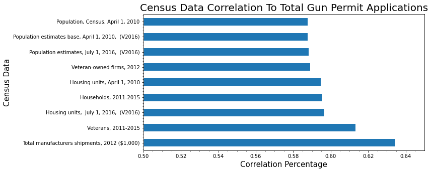

### Conclusions

As part of this analysis NCIS and census data was used to answer questions related to gun permit applications in the united states and if any census data could be used to determine the volume of permit applications in a given state and the following conclusions were drawn.

> 1: All states had an increase in gun permit applications over the time covered in the NCIS data. Of these states Iowa had the highest percentage increase overall with a 4.8% increase in gun permit applications.  
> 2: To determine if there were any other idiosyncracies I plotted the permit applications over the period for Iowa with Utah. Utah was selected due to an initial flaw in my analysis which showed Utah as having the largest percent increase. This flaw exposed that an external factor led to a large number of gun permit applications from 2010-2012. Additional data could be brought in to determine if a cause could be found for this strange data.  
> 3: Overall gun permit applications remained relatively flat until 2008 at which time they began to climb and spiked in 2016. Permit applications decreased somewhat after that time. This was determined through plotting total permit applications against dates from the NCIS data.  
> 4: The census data covered a different period than the NCIS data, so to determine what census data could be correlated to permit applications. Once this was done a the NCIS and census data were correlated to determine that manufacturing output had a nearly 63.4% correlation to high total permit applications per state.

[output not shown]